# Explorative data analysis and data visualization in R

Now we would like to generate the same plot, but for all of the measured circumfences in the dataset. One useful way for this is so-called facetting. This requires some reshaping of the data:

```r
body_fat_melt <- bd_fat_df_BMI %>%
                 melt(id.vars=c('density', 'percent.fat','age','weight','height'))
```

Melt is using the columns you are listing to create a unique ID, then it stacks the remaining columns in 2 columns: one containing the variable name and the other containing the relative value (more info: https://i1.wp.com/www.studytrails.com/wp-content/uploads/2016/09/reshape.png).

**Question:** Compare bd_fat_df_BMI and body_fat_melt (e.g. using head() and dim()). What are the differences?

You’ll see that the circumfence columns have been combined to two columns: A variable column containing the original column name and a value column containing the original value. In contrast, the columns defined as ID variables have not been aggregated.

Now we can generate the scatterplot:

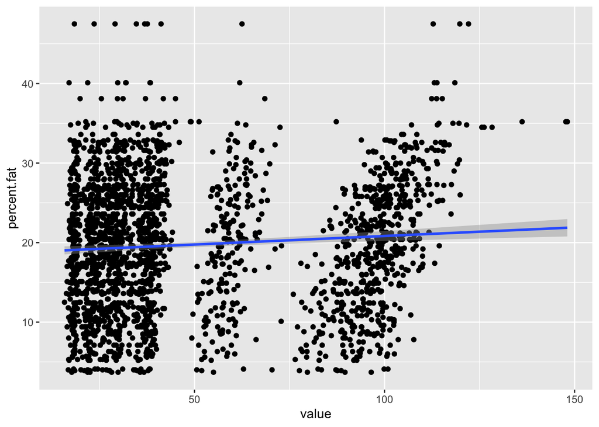

```r
#First we use a similar command as in the previous scatterplot
plot_scatter <- ggplot(body_fat_melt, aes(value, percent.fat))+
                      geom_point() +
                      geom_smooth(method= "lm")
plot_scatter
```

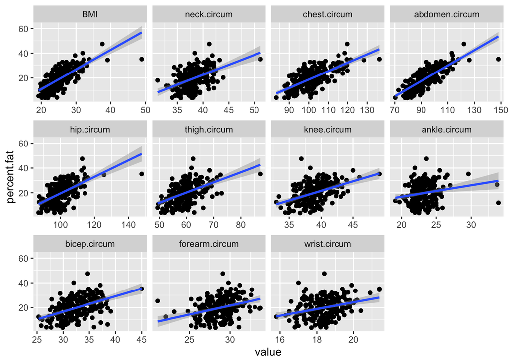

```r
#You can see clusters of point, because all the circumfences are plotted. But we want to plot each circumfence in a seperate plot and with an adjusted x axis.

plot_scatter_facet<-plot_scatter+
                      facet_wrap(~variable, scales = 'free_x')
plot_scatter_facet
```

You can see that some of the circumfences are stronger associated with the percent.fat. One way to quantify the strength of association is correlation:

```r
# To calculate Pearson correlation of the variable percentage of fat to all the others
cor(bd_fat_df_BMI, bd_fat_df_BMI$percent.fat)
```

```
##                      [,1]
## age             0.2837040
## height         -0.1341383
## weight          0.5625083
## BMI             0.7083895
## density        -0.9857171
## percent.fat     1.0000000
## neck.circum     0.4618421
## chest.circum    0.6857126
## abdomen.circum  0.7977833
## hip.circum      0.5748879
## thigh.circum    0.4989770
## knee.circum     0.4417906
## ankle.circum    0.1973933
## bicep.circum    0.4552812
## forearm.circum  0.3375754
## wrist.circum    0.2952747
```

**Question:** Do the derived correlation values agree with your expectations form the plot?

## Excercises - Now it is your turn!

For this practical session we have downloaded 2 datasets from the [TidyTuesday commnunity](https://www.tidytuesday.com/).

1. You can find some inspiration from other users on [TidyTuesday Twitter](https://twitter.com/hashtag/tidytuesday?f=live).
2. This [cheatsheet](https://rstudio.com/wp-content/uploads/2015/03/ggplot2-cheatsheet.pdf) gives a good overview of commands (we didn’t go through all!).
3. Once you are familiar with the basic package, here are some useful [extensions](http://www.ggplot2-exts.org/gallery/)

### Example 1: Passwords and their security

The dataset `password_dataset.csv`has this structure:

| variable | class | description |
| --- | --- | --- |
| rank | double | popularity in their database of released passwords |
| password | character | Actual text of the password |
| category | character | What category does the password fall in to? |
| value | double | Time to crack by online guessing |
| time_unit | character | Time unit to match with value |
| offline_crack_sec | double | Time to crack offline in seconds |
| rank_alt | double | Rank 2 |
| strength | double | Strength = quality of password where highest value means highest quality |
| font_size | double | Used to create the graphic for KIB |

#### **Questions:**

1. Import the password dataset `password_dataset.csv`
2. Look at the dataset. Does it need to be modified?
3. How many rows are in the dataframe?
4. What is the most secure password?
5. What is the largest password category?
6. Sort the data_base according to the alternative rank
7. What is the category with the highest strength on average?
8. How does the password lenght correlate with its strength?

#### **Tips:**

- You can use function such as `is.na()` or `na.omit()` to see if there are any missing values
- You should use `group_by`, `summarise` and `n`
- You should use `str_length`

### Example 2: Spotify songs and their popularity

| variable | class | description |
| --- | --- | --- |
| track_id | character | Song unique ID |
| track_name | character | Song Name |
| track_artist | character | Song Artist |
| track_popularity | double | Song Popularity (0-100) where higher is better |
| track_album_id | character | Album unique ID |
| track_album_name | character | Song album name |
| track_album_release_date | character | Date when album released |
| playlist_name | character | Name of playlist |
| playlist_id | character | Playlist ID |
| playlist_genre | character | Playlist genre |
| playlist_subgenre | character | Playlist subgenre |
| danceability | double | Danceability describes how suitable a track is for dancing based on a combination of musical elements including tempo, rhythm stability, beat strength, and overall regularity. A value of 0.0 is least … |
| energy | double | Energy is a measure from 0.0 to 1.0 and represents a perceptual measure of intensity and activity. Typically, energetic tracks feel fast, loud, and noisy. For example, death metal has high energy, whi… |
| key | double | The estimated overall key of the track. Integers map to pitches using standard Pitch Class notation . E.g. 0 = C, 1 = C♯/D♭, 2 = D, and so on. If no key was detected, the value is -1. |
| loudness | double | The overall loudness of a track in decibels (dB). Loudness values are averaged across the entire track and are useful for comparing relative loudness of tracks. Loudness is the quality of a sound that… |
| mode | double | Mode indicates the modality (major or minor) of a track, the type of scale from which its melodic content is derived. Major is represented by 1 and minor is 0. |
| speechiness | double | Speechiness detects the presence of spoken words in a track. The more exclusively speech-like the recording (e.g. talk show, audio book, poetry), the closer to 1.0 the attribute value. Values above 0.… |
| acousticness | double | A confidence measure from 0.0 to 1.0 of whether the track is acoustic. 1.0 represents high confidence the track is acoustic. |
| instrumentalness | double | Predicts whether a track contains no vocals. “Ooh” and “aah” sounds are treated as instrumental in this context. Rap or spoken word tracks are clearly “vocal”. The closer the instrumentalness value is… |
| liveness | double | Detects the presence of an audience in the recording. Higher liveness values represent an increased probability that the track was performed live. A value above 0.8 provides strong likelihood that the… |
| valence | double | A measure from 0.0 to 1.0 describing the musical positiveness conveyed by a track. Tracks with high valence sound more positive (e.g. happy, cheerful, euphoric), while tracks with low valence sound mo… |
| tempo | double | The overall estimated tempo of a track in beats per minute (BPM). In musical terminology, tempo is the speed or pace of a given piece and derives directly from the average beat duration. |
| duration_ms | double | Duration of song in milliseconds |

#### **Questions:**

Import `spotify_songs.csv`

1. Which artist has the most popular songs on average in the 2000s?
2. Which artist made songs in most of the years?
3. Who are the top 5 track artist by playlist genre in the last 10 years?
4. How are songs from Kendrick Lamar different to those from Rihanna?
5. Are the song features (speechiness, acousticness,…) correlated?
6. How did danceability in EDM evolve over time?

#### Tips:__

You might have to change the variable classes to numeric. One way to do it is shown in the example, but you can also use mutate() for example.

```r
spotify_songs<-read_csv('spotify_songs.csv')
```

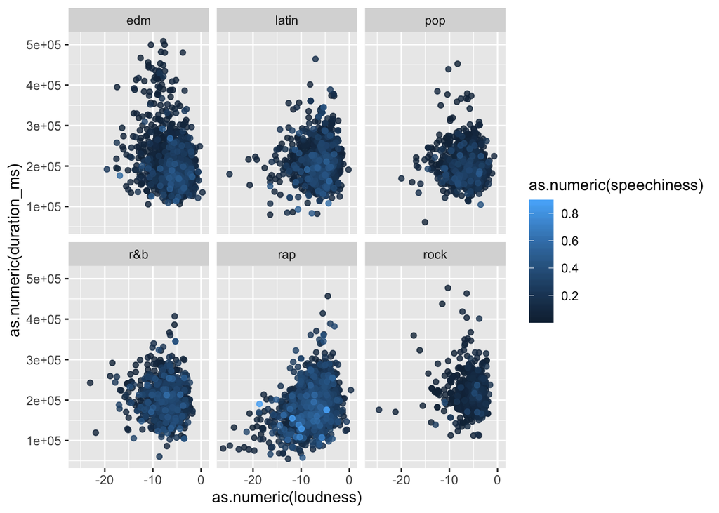

```r
#I wanty to look only at the songs from 2019 and want to have the most speechy songs on top
spotify_2019<-spotify_songs%>%filter(track_album_release_date=='2019')%>%arrange(speechiness)
#Now the plotting:
ggplot(spotify_2019,aes(as.numeric(loudness), as.numeric(duration_ms)))+
  geom_point(aes(color=as.numeric(speechiness)), alpha=0.8)+
  facet_wrap(~playlist_genre)
```

```r
ggsave('~/spotify_songs_example.pdf')
```